# Ring-Tailed Lemur Project

## Introduction

Ring-tailed lemurs (*Lemur catta*) are a semi-terrestrial, diurnal species with a limited range of Southern Madasgascar (Sauther 1998). Similar to cercopithecine monkeys, ring-tailed lemurs have complex social troops where adult males, females, and immature offspring are present (Jolly 1996; Nakamich & Koyama 1996). Previous studies have found that ring-tailed lemurs clearly have a female-dominant social structure and form dominance hierarchies within female and male groups as well (Jolly 1996; Kappeler 1990; Budnitz and Dainis 1975). In captivity, ring-tailed lemurs tend to live in much smaller troops compared to those found in the wild and they don’t have to compete as much for resources. However, even in a captive setting, adult female ring-tailed lemurs still outrank males (Taylor 1986; Kappeler 1990).

Dominance rankings within troops influence certain social behaviors, such as grooming, greeting, and social proximity (Nakamich & Koyama 1996). After creating a dominance hierarchy based on agonistic displays, Nakamich & Koyama (1996) found that subordinate individuals were significantly more likely to greet and groom dominant individuals than *vice versa* and males spent significantly more time alone than the higher-ranking females.

Using agonistic interactions to determine dominance rank among ring-tailed lemurs is an extremely common approach when studying both wild and captive individuals (Taylor 1986; Kappeler 1990; Gould 1996). Furthermore, Taylor (1986) found that agonistic interactions were more likely to occur between unrelated individuals and distant kin than between closely related kin, making it an ideal approach when multiple families make up the study troop. Since the small ring-tailed lemur population observed in this study only included one breeding pair and their two female offspring, agonistic behaviors were not commonly observed. Therefore, greeting behaviors were used as a determinant for dominance rank instead where the action of approaching and greeting others indicated a lower ranking.

The main purpose of this study was to practice collecting behavioral data on a group of ring-tailed lemurs and to investigate how their dominance rank effects grooming behaviors and social proximity. I hypothesized that 1) the male will greet the females more than *vice versa*, 2) subordinate individuals will initiate grooming bouts with dominant individuals more often than *vice versa*, 3) dominant individuals will end grooming bouts more often than *vice versa*, and 4) subordinate individuals will spend more time alone than dominant individuals.

## Methods

I conducted this study at the Franklin Park Zoo in Boston, Massachusetts. The group of captive ring-tailed lemurs at the zoo included one adult male, and three adult females (exact ages unknown), which I named King Julian, Everest, May, and Zoey, respectively. The zookeepers informed me that King Julian and Everest are the breeding pair and May and Zoey are their offspring. I partly used this knowledge in conjunction with the approaching and greeting behaviors to determine rank order.

I collected behavioral data using the focal animal sampling method (Altmann 1974) and every individual was a focal animal. Each focal lasted 20 minutes and a total of 14 focal observations were collected. I recorded all approaching, greeting, and grooming behaviors via the focal sampling method as well as contact ID and any individual <1m, <5m, and <10m away from the focal at 2 minute intervals. As described by Nakamich & Koyama (1996), greeting consisted of one individual licking another’s muzzle and/or touching it with their own muzzle. In unidirectional grooming, one individual received grooming from another and did not reciprocate. In mutual grooming, two animals groomed one other simultaneously. I also recorded which individuals initiated and ended each grooming bout. Greeting and grooming behaviors were also collected *ad libitum* if necessary. I combined the focal animal sampling with the *ad libitum* data for analysis.

## Data Analyses

```r
library(dplyr)
library(tidyverse)
library(curl)
```

Importing My Data

```r
lemurs_full<- curl("https://raw.githubusercontent.com/langley1/Ring-tailed-Lemur-Project/master/RTL%20dataset.csv")
lemurs_full<- read.csv(lemurs_full, header = TRUE) #full dataset
head(lemurs_full)
```

```
##   Data_Collector Focal_ID    Date Time_Start Point_Sample Nearest_Neighbor
## 1   Laura Angley       EV No Date 2:12:02 PM            0               MY
## 2   Laura Angley       EV No Date 2:17:20 PM            2               MY
## 3   Laura Angley       EV No Date 2:18:08 PM            4               MY
## 4   Laura Angley       EV No Date 2:18:36 PM            6               MY
## 5   Laura Angley       EV No Date 2:19:25 PM            8               MY
## 6   Laura Angley       EV No Date 2:20:16 PM           10               MY
##   Focal_Number Point_Behavior Behavior_Tally Ad_Libitum Location
## 1         FS01            RV/         SC_MY/             FBR_RK/
## 2         FS01         SC_MY/                            FBR_RK/
## 3         FS01         SC_MY/                            FBR_RK/
## 4         FS01        GRM_MY/                            FBR_RK/
## 5         FS01            RV/                            FBR_RK/
## 6         FS01        GRM_MY/                            FBR_RK/
##   Contact_ID X.1_ID X.5_ID X.10_ID
## 1        MY/    ZY/    KJ/
## 2        MY/    ZY/    KJ/
## 3        MY/    ZY/    KJ/
## 4        MY/    ZY/    KJ/
## 5            MY/ZY/            KJ/
## 6        MY/    ZY/            KJ/
```

```r
i <- sapply(lemurs_full, is.factor) #I need to turn the factor data into characters in order to transform and unnest later on
lemurs_full[i] <- lapply(lemurs_full[i], as.character)
lemurs_full %>% mutate_if(is.factor, as.character) -> lemurs_full

lemurs <- lemurs_full %>% select(Focal_ID, Point_Sample, Nearest_Neighbor, Point_Behavior, Behavior_Tally, Ad_Libitum, Contact_ID, X.1_ID, X.5_ID, X.10_ID) #only selecting the columns I'll need
head(lemurs)
```

```
##   Focal_ID Point_Sample Nearest_Neighbor Point_Behavior Behavior_Tally
## 1       EV            0               MY            RV/         SC_MY/
## 2       EV            2               MY         SC_MY/
## 3       EV            4               MY         SC_MY/
## 4       EV            6               MY        GRM_MY/
## 5       EV            8               MY            RV/
## 6       EV           10               MY        GRM_MY/
##   Ad_Libitum Contact_ID X.1_ID X.5_ID X.10_ID
## 1                   MY/    ZY/    KJ/
## 2                   MY/    ZY/    KJ/
## 3                   MY/    ZY/    KJ/
## 4                   MY/    ZY/    KJ/
## 5                       MY/ZY/            KJ/
## 6                   MY/    ZY/            KJ/
```

Creating data frames for each individual animal ID

```r
EV_full <- lemurs %>% filter(Focal_ID == "EV")
KJ_full <- lemurs %>% filter(Focal_ID == "KJ")
MY_full <- lemurs %>% filter(Focal_ID == "MY")
ZY_full <- lemurs %>% filter(Focal_ID == "ZY")
```

### Transforming and Unnestting Each Animal’s Necessary Behavior Data

**Everest’s Data**

```r
EV_1<- EV_full %>% transform(Behavior_Tally = strsplit(Behavior_Tally, "/")) %>% unnest(Behavior_Tally,keep_empty=TRUE)
head(EV_1)
```

```
## # A tibble: 6 x 10
##   Focal_ID Point_Sample Nearest_Neighbor Point_Behavior Behavior_Tally
##   <chr>           <int> <chr>            <chr>          <chr>
## 1 EV                  0 MY               RV/            SC_MY
## 2 EV                  2 MY               SC_MY/         <NA>
## 3 EV                  4 MY               SC_MY/         <NA>
## 4 EV                  6 MY               GRM_MY/        <NA>
## 5 EV                  8 MY               RV/            <NA>
## 6 EV                 10 MY               GRM_MY/        <NA>
## # … with 5 more variables: Ad_Libitum <chr>, Contact_ID <chr>,
## #   X.1_ID <chr>, X.5_ID <chr>, X.10_ID <chr>
```

```r
EV_2<- EV_full %>% transform(Point_Behavior = strsplit(Point_Behavior, "/")) %>% unnest(Point_Behavior, keep_empty=TRUE)
head(EV_2)
```

```
## # A tibble: 6 x 10
##   Focal_ID Point_Sample Nearest_Neighbor Point_Behavior Behavior_Tally
##   <chr>           <int> <chr>            <chr>          <chr>
## 1 EV                  0 MY               RV             SC_MY/
## 2 EV                  2 MY               SC_MY          ""
## 3 EV                  4 MY               SC_MY          ""
## 4 EV                  6 MY               GRM_MY         ""
## 5 EV                  8 MY               RV             ""
## 6 EV                 10 MY               GRM_MY         ""
## # … with 5 more variables: Ad_Libitum <chr>, Contact_ID <chr>,
## #   X.1_ID <chr>, X.5_ID <chr>, X.10_ID <chr>
```

```r
#don't need to do her ad_libitum data because all behavior entries were single entries
```

**King Julian’s Data**

```r
KJ_1<- KJ_full %>% transform(Behavior_Tally = strsplit(Behavior_Tally, "/")) %>% unnest(Behavior_Tally,keep_empty=TRUE)
(KJ_1)
```

```
## # A tibble: 35 x 10
##    Focal_ID Point_Sample Nearest_Neighbor Point_Behavior Behavior_Tally
##    <chr>           <int> <chr>            <chr>          <chr>
##  1 KJ                  0 EV               SGR/           <NA>
##  2 KJ                  2 EV               SGR/           <NA>
##  3 KJ                  4 EV               SGR/           <NA>
##  4 KJ                  6 EV               RPO/           <NA>
##  5 KJ                  8 MY               RPO/           <NA>
##  6 KJ                 10 MY               RPO/           APA_MY
##  7 KJ                 12 MY               RV/            GTA_MY
##  8 KJ                 14 MY               SGR/           <NA>
##  9 KJ                 16 MY               SGR/           <NA>
## 10 KJ                 18 MY               SGR/           <NA>
## # … with 25 more rows, and 5 more variables: Ad_Libitum <chr>,
## #   Contact_ID <chr>, X.1_ID <chr>, X.5_ID <chr>, X.10_ID <chr>
```

```r
KJ_2<- KJ_full %>% transform(Ad_Libitum = strsplit(Ad_Libitum, "/")) %>% unnest(Ad_Libitum, keep_empty=TRUE)

# don't need to do his point behavior data
```

**May’s Data**

```r
MY_1<- MY_full %>% transform(Behavior_Tally = strsplit(Behavior_Tally, "/")) %>% unnest(Behavior_Tally,keep_empty=TRUE)

MY_2<- MY_full %>% transform(Ad_Libitum = strsplit(Ad_Libitum, "/")) %>% unnest(Ad_Libitum, keep_empty=TRUE)

# don't need to do her point behavior data
```

**Zoey’s Data**

```r
ZY_1<- ZY_full %>% transform(Behavior_Tally = strsplit(Behavior_Tally, "/")) %>% unnest(Behavior_Tally,keep_empty=TRUE)

ZY_2<- ZY_full %>% transform(Point_Behavior = strsplit(Point_Behavior, "/")) %>% unnest(Point_Behavior, keep_empty=TRUE)

ZY_3<- ZY_full %>% transform(Ad_Libitum = strsplit(Ad_Libitum, "/")) %>% unnest(Ad_Libitum, keep_empty=TRUE)
```

### Greeting Behavior

**Everest greeting May**

```r
EV_GT_MY_1<- EV_1 %>% filter(Behavior_Tally %in% c("GTA_MY","APA_MY")) #filtering out the greeting and approaching behaviors from Behavior_Tally column
EV_GT_MY_2<- EV_2 %>% filter(Point_Behavior == "GTA_MY") #filtering out the greeting and approaching behaviors from Point_Behavior column
EV_GT_MY_3<- KJ_2 %>% filter(Ad_Libitum == "EV_APA_MY")
EV_GT_MY_4<- ZY_3 %>% filter(Ad_Libitum %in% c("EV_GTA_MY", "EV_APA_MY"))
EV_GT_MY<- sum(nrow(EV_GT_MY_1),nrow(EV_GT_MY_2),nrow(EV_GT_MY_3),nrow(EV_GT_MY_4)) #adding up the number of rows from each for my final obj because I only care about how many times in total EV greeted MY
EV_GT_MY
```

```
## [1] 8
```

**Everest greeting King Julian**

```r
EV_GT_KJ_1<- EV_1 %>% filter(Behavior_Tally == "APA_KJ")
EV_GT_KJ<- nrow(EV_GT_KJ_1)
EV_GT_KJ
```

```
## [1] 1
```

**Zoey greeting King Julian**

```r
ZY_GT_KJ_1<- EV_1 %>% filter(Ad_Libitum == "ZY_GTA_KJ/")
ZY_GT_KJ_2<- ZY_1 %>% filter(Behavior_Tally == "GTA_KJ")
ZY_GT_KJ<- sum(nrow(ZY_GT_KJ_1),nrow(ZY_GT_KJ_2))
ZY_GT_KJ
```

```
## [1] 3
```

**May greeting King Julian**

```r
MY_GT_KJ_1<- EV_1 %>% filter(Ad_Libitum == "MY_GTA_KJ/")
MY_GT_KJ_2<- MY_1 %>% filter(Behavior_Tally == "APA_KJ")
MY_GT_KJ_3<- ZY_3 %>% filter(Ad_Libitum == "MY_GTA_KJ")
MY_GT_KJ<- sum(nrow(MY_GT_KJ_1),nrow(MY_GT_KJ_2),nrow(MY_GT_KJ_3))
MY_GT_KJ
```

```
## [1] 2
```

**King Julian greeting Zoey**

```r
KJ_GT_ZY_1<- KJ_1 %>% filter(Point_Behavior == "APA_ZY/")
KJ_GT_ZY_2<- MY_2 %>% filter(Ad_Libitum == "KJ_APA_ZY")
KJ_GT_ZY_3<- ZY_2 %>% filter(Point_Behavior == "APR_KJ")
KJ_GT_ZY<- sum(nrow(KJ_GT_ZY_1),nrow(KJ_GT_ZY_2),nrow(KJ_GT_ZY_3))
KJ_GT_ZY
```

```
## [1] 4
```

**King Julian greeting Everest**

```r
KJ_GT_EV_1<- KJ_1 %>% filter(Behavior_Tally == "APA_EV")
KJ_GT_EV_2<- EV_1 %>% filter(Behavior_Tally == "GTR_KJ")
KJ_GT_EV<- sum(nrow(KJ_GT_EV_1),nrow(KJ_GT_EV_2))
KJ_GT_EV
```

```
## [1] 2
```

**Zoey greeting Everest**

```r
ZY_GT_EV_1<- KJ_2 %>% filter(Ad_Libitum == "ZY_GTA_EV")
ZY_GT_EV_2<- ZY_1 %>% filter(Behavior_Tally == "APA_EV")
ZY_GT_EV<- sum(nrow(ZY_GT_EV_1),nrow(ZY_GT_EV_2))
ZY_GT_EV
```

```
## [1] 3
```

**May greeting Zoey**

```r
MY_GT_ZY_1<- KJ_2 %>% filter(Ad_Libitum == "MY_GTA_ZY")
MY_GT_ZY<- nrow(MY_GT_ZY_1)
MY_GT_ZY
```

```
## [1] 1
```

**May greeting Everest**

```r
MY_GT_EV_1<- KJ_2 %>% filter(Ad_Libitum == "MY_APA_EV")
MY_GT_EV_2<- MY_1 %>% filter(Behavior_Tally == "GTA_EV")
MY_GT_EV<- sum(nrow(MY_GT_EV_1),nrow(MY_GT_EV_2))
MY_GT_EV
```

```
## [1] 3
```

**Zoey greeting May**

```r
ZY_GT_MY_1<- ZY_1 %>% filter(Behavior_Tally %in% c("APA_MY","GTA_MY"))
ZY_GT_MY<- nrow(ZY_GT_MY_1)
ZY_GT_MY
```

```
## [1] 2
```

**King Julian greeting May**

```r
KJ_GT_MY_1<- KJ_1 %>% filter(Behavior_Tally %in% c("GTA_MY","APA_MY"))
KJ_GT_MY<- nrow(KJ_GT_MY_1)
KJ_GT_MY
```

```
## [1] 3
```

Creating a matrix to show the greeting behaviors

```r
GT_matrix<- matrix(c(0,1,8,0,2,0,3,4,3,2,0,1,3,3,2,0),nrow = 4, ncol = 4, byrow = T)
dimnames(GT_matrix)<- list(c("EV","KJ","MY","ZY"),c("EV","KJ","MY","ZY"))
```

Creating a new dataframe

```r
rank<- c(1,2,3,4)
ids<- c("MY","EV","ZY","KJ")
ranks<- data.frame(IDs=ids, Rank=rank)
summary(ranks)
```

```
##  IDs         Rank
##  EV:1   Min.   :1.00
##  KJ:1   1st Qu.:1.75
##  MY:1   Median :2.50
##  ZY:1   Mean   :2.50
##         3rd Qu.:3.25
##         Max.   :4.00
```

### Grooming Behavior

**Subordinates Grooming Dominants** (includes any time a subordinate iniated a grooming bout or groomed a dominant individual unidirectionally)

```r
sub_gr_dom_1<- EV_1 %>% filter(Behavior_Tally %in% c("GRIA_MY","GRA_MY"))
sub_gr_dom_2<- MY_1 %>% filter(Behavior_Tally %in% c("GRIR_KJ","GRIR_EV"))
sub_gr_dom_3<- ZY_2 %>% filter(Point_Behavior == "GRIR_KJ")
sub_gr_dom_4<- ZY_1 %>% filter(Behavior_Tally == "GRIR_KJ")
sub_gr_dom_5<- ZY_3 %>% filter(Ad_Libitum %in% c("EV_GRIA_MY","EV_GRA_MY"))
sub_gr_dom<- sum(nrow(sub_gr_dom_1),nrow(sub_gr_dom_2),nrow(sub_gr_dom_3),nrow(sub_gr_dom_4),nrow(sub_gr_dom_5))
sub_gr_dom
```

```
## [1] 9
```

**Dominants Grooming Subordinates** (includes any time a dominant iniated a grooming bout or groomed a subordinant individual unidirectionally)

```r
dom_gr_sub_1<- KJ_2 %>% filter(Ad_Libitum %in% c("MY_GRIA_EV", "MY_GRA_EV"))
dom_gr_sub_2<- EV_1 %>% filter(Behavior_Tally == "GRIR_MY")
dom_gr_sub_3<- MY_1 %>% filter(Point_Behavior == "GRA_EV/" | Behavior_Tally == "GRIA_EV") #rememebr to add the / after the Point behavior here because we never unnessted it since they were all single behavior entries
dom_gr_sub_4<- ZY_1 %>% filter(Behavior_Tally == "GRIA_KJ")
dom_gr_sub_5<- ZY_3 %>% filter(Ad_Libitum %in% c("MY_GRIA_EV","MY_GRA_EV"))
dom_gr_sub<- sum(nrow(dom_gr_sub_1),nrow(sub_gr_dom_2),nrow(sub_gr_dom_3),nrow(sub_gr_dom_4),nrow(sub_gr_dom_5))
dom_gr_sub
```

```
## [1] 10
```

Finding the percentage of times subordinates groom dominants and dominants groom subordinates

```r
sub_gr_dom_perc<- (sub_gr_dom/140)*100 # I'm dividing it by 140 because my raw data has a total of 14 focal observations with 10 point samples each focal observations
sub_gr_dom_perc
```

```
## [1] 6.428571
```

```r
dom_gr_sub_perc<- (dom_gr_sub/140)*100
dom_gr_sub_perc
```

```
## [1] 7.142857
```

```r
# Creating a data frame to show grooming order and percentage of grooming between subs and doms
percentage<- c(sub_gr_dom_perc,dom_gr_sub_perc)
grooming_order<- c("Subordinate to Dominant","Dominant to Subordinate")
gr_df<- data.frame("Grooming Order"=grooming_order, Percentage=percentage)
```

Running a binomal test for the grooming order initiation data

```r
binom_test<- binom.test(c(sub_gr_dom,dom_gr_sub), p=0.5, conf.level = 0.95)
binom_test
```

```
##
##  Exact binomial test
##
## data:  c(sub_gr_dom, dom_gr_sub)
## number of successes = 9, number of trials = 19, p-value = 1
## alternative hypothesis: true probability of success is not equal to 0.5
## 95 percent confidence interval:
##  0.2444747 0.7113568
## sample estimates:
## probability of success
##              0.4736842
```

*There is no significant difference between the number of times subordinates iniated grooming/ groomed dominants and vice versa*

**Ending Grooming Bouts (includes any time a grooming bout was terminated by an individual)**

```r
#Subordinates ending grooming bouts with dominants
sub_gr_end_dom_1<- EV_1 %>% filter(Behavior_Tally == "GREA_MY")
sub_gr_end_dom_2<- MY_1 %>% filter(Behavior_Tally == "GRER_EV")
sub_gr_end_dom_3<- ZY_3 %>% filter(Ad_Libitum == "EV_GREA_MY")
sub_gr_end_dom<- sum(nrow(sub_gr_end_dom_1),nrow(sub_gr_end_dom_2),nrow(sub_gr_end_dom_3))
sub_gr_end_dom
```

```
## [1] 3
```

```r
# dominants ending grooming bouts with subordinates
dom_gr_end_sub_1<- KJ_2 %>% filter(Ad_Libitum == "MY_GREA_EV")
dom_gr_end_sub_2<- MY_1 %>% filter(Behavior_Tally == "GREA_KJ")
dom_gr_end_sub_3<- ZY_1 %>% filter(Behavior_Tally == "GREA_KJ")
dom_gr_end_sub<- sum(nrow(dom_gr_end_sub_1),nrow(dom_gr_end_sub_2),nrow(dom_gr_end_sub_3))
dom_gr_end_sub
```

```
## [1] 4
```

Finding the percentage of times subordinates ended grooming with dominants and dominants ended grooming with subordinates

```r
sub_gr_end_dom_perc<- (sub_gr_end_dom/140)*100
dom_gr_end_sub_perc<- (dom_gr_end_sub/140)*100

# Creating a data frame to show grooming order and percentage of groom ending between subs and doms
end_percentage<- c(sub_gr_end_dom_perc,dom_gr_end_sub_perc)
end_grooming_order<- c("Subordinate to Dominant","Dominant to Subordinate")
gr_end_df<- data.frame("Grooming Order"=end_grooming_order, Percentage=end_percentage)
```

Running a binomal test for grooming order termination data

```r
end_binom_test<- binom.test(c(dom_gr_end_sub,sub_gr_end_dom), p=0.5, conf.level = 0.95)
end_binom_test
```

```
##
##  Exact binomial test
##
## data:  c(dom_gr_end_sub, sub_gr_end_dom)
## number of successes = 4, number of trials = 7, p-value = 1
## alternative hypothesis: true probability of success is not equal to 0.5
## 95 percent confidence interval:
##  0.1840516 0.9010117
## sample estimates:
## probability of success
##              0.5714286
```

*There is no significant difference between the number of times subs ended grooming bouts with dominants and vice versa*

### Mutual Grooming between pairs of individuals

**Everest and May**

```r
EV_MY_GRM_1<- EV_2 %>% filter(Point_Behavior == "GRM_MY")
EV_MY_GRM_2<- EV_1 %>% filter(Behavior_Tally == "GRM_MY")
EV_MY_GRM_3<- ZY_3 %>% filter(Ad_Libitum %in% c("EV_GRM_MY","MY_GRM_EV"))
EV_MY_GRM<- sum(nrow(EV_MY_GRM_1),nrow(EV_MY_GRM_2),nrow(EV_MY_GRM_3))
EV_MY_GRM
```

```
## [1] 7
```

```r
EV_MY_GRM_perc<- EV_MY_GRM/140*100
EV_MY_GRM_perc
```

```
## [1] 5
```

**May and King Julian**

```r
MY_KJ_GRM_1<- MY_1 %>% filter(Point_Behavior == "GRM_KJ/" | Behavior_Tally == "GRM_KJ")
MY_KJ_GRM<- nrow(MY_KJ_GRM_1)
MY_KJ_GRM
```

```
## [1] 4
```

```r
MY_KJ_GRM_perc<- MY_KJ_GRM/140*100
MY_KJ_GRM_perc
```

```
## [1] 2.857143
```

**Zoey and King Julian**

```r
ZY_KJ_GRM_1<- ZY_2 %>% filter(Point_Behavior == "GRM_KJ")
ZY_KJ_GRM_2<- ZY_1 %>% filter(Behavior_Tally == "GRM_KJ")
ZY_KJ_GRM<- sum(nrow(ZY_KJ_GRM_1),nrow(ZY_KJ_GRM_2))
ZY_KJ_GRM
```

```
## [1] 5
```

```r
ZY_KJ_GRM_perc<- ZY_KJ_GRM/140*100
ZY_KJ_GRM_perc
```

```
## [1] 3.571429
```

Creating a new dataframe for mutual grooming

```r
GRM_percentage<- c(EV_MY_GRM_perc,MY_KJ_GRM_perc,ZY_KJ_GRM_perc)
GRM_pairs<- c("Everest & May", "May & King Julian","Zoey & King Julian")
GRM_df<- data.frame("Mutual Grooming Pairs"=GRM_pairs,"Percentage"=GRM_percentage)
```

Running a binomal test between EV-MY mutual grooming and ZY-KJ mutual grooming

```r
GRM_binom_test<- binom.test(c(EV_MY_GRM,ZY_KJ_GRM), p=0.5, conf.level = 0.95)
GRM_binom_test
```

```
##
##  Exact binomial test
##
## data:  c(EV_MY_GRM, ZY_KJ_GRM)
## number of successes = 7, number of trials = 12, p-value = 0.7744
## alternative hypothesis: true probability of success is not equal to 0.5
## 95 percent confidence interval:
##  0.2766697 0.8483478
## sample estimates:
## probability of success
##              0.5833333
```

*There is no significant difference between EV-MY mututal grooming and ZY-KJ mutual grooming*

### Social Proximity Data

**Looking at how many point samples each individual spent alone (contact Id = 0 and <1m = 0)**

```r
EV_alone<- EV_1 %>% filter(Contact_ID == "" & X.1_ID == "")
EV_alone<- nrow(EV_alone)
EV_alone #number of point samples where EV was alone
```

```
## [1] 4
```

```r
EV_alone_perc<- EV_alone/140*100
EV_alone_perc #percentage of total point samples where EV was alone
```

```
## [1] 2.857143
```

```r
# King Julian
KJ_alone<- KJ_1 %>% filter(Contact_ID == "" & X.1_ID == "")
KJ_alone<- nrow(KJ_alone)
KJ_alone
```

```
## [1] 24
```

```r
KJ_alone_perc<- KJ_alone/140*100
KJ_alone_perc
```

```
## [1] 17.14286
```

```r
# May
MY_alone<- MY_1 %>% filter(Contact_ID == "" & X.1_ID == "")
MY_alone<- nrow(MY_alone)
MY_alone
```

```
## [1] 5
```

```r
MY_alone_perc<- MY_alone/140*100
MY_alone_perc
```

```
## [1] 3.571429
```

```r
# Zoey
ZY_alone<- ZY_1 %>% filter(Contact_ID == "" & X.1_ID == "")
ZY_alone<- nrow(ZY_alone)
ZY_alone
```

```
## [1] 20
```

```r
ZY_alone_perc<- ZY_alone/140*100
ZY_alone_perc
```

```
## [1] 14.28571
```

Adding new columns to my ranks dataframe

```r
ranks$alone<- c(MY_alone,EV_alone,ZY_alone,KJ_alone) #creating a new columns for the number of point samples where each individual was alone
alone<- ranks$alone

ranks$perc_alone<- c(MY_alone_perc,EV_alone_perc,ZY_alone_perc,KJ_alone_perc) #creating a new column for the percentage of total point samples where each individual was alone
perc_alone<- ranks$perc_alone
perc_alone
```

```
## [1]  3.571429  2.857143 14.285714 17.142857
```

```r
ranks$IDs <- as.character(ranks$IDs)
ranks$IDs <- factor(ranks$IDs, levels=c("MY", "EV", "ZY","KJ")) #I didn't want "IDs" to be listed alphabetically in the graph so first I switched it to a character list and then back to a factor list in the order I wanted
```

Trying out some nonparametric tests on my ranks vs perc_alone data

```r
# Kruskal Wallis Test - non parametric ANOVA

Krusk_test<-kruskal.test(data= ranks, perc_alone ~ IDs) #I feel like this test isn't applicable to my data because I don't have a range of perc_alone values for each ID, I just have one single value for each ID. By looking at the data, it seems like theres a pretty big difference between EV/MY and ZY/KJ but the test shows no significant difference across IDs
Krusk_test
```

```
##
##  Kruskal-Wallis rank sum test
##
## data:  perc_alone by IDs
## Kruskal-Wallis chi-squared = 3, df = 3, p-value = 0.3916
```

```r
library(mblm) #needed for the nonparametric linear regression
library(psych) #needed for the correlation test
#This is the Spearman Correlation

cor<- cor.test( ~ Rank + perc_alone,
         data=ranks,
         method = "spearman")
cor
```

```
##
##  Spearman's rank correlation rho
##
## data:  Rank and perc_alone
## S = 2, p-value = 0.3333
## alternative hypothesis: true rho is not equal to 0
## sample estimates:
## rho
## 0.8
```

```r
# This is the Kendall–Theil Sen Siegel nonparametric linear regression

model.k<- mblm(perc_alone ~ Rank,
               data=ranks)
summary(model.k)
```

```
##
## Call:
## mblm(formula = perc_alone ~ Rank, dataframe = ranks)
##
## Residuals:
##          1          2          3          4
##  4.441e-16 -5.655e+00  8.333e-01 -1.250e+00
##
## Coefficients:
##             Estimate     MAD V value Pr(>|V|)
## (Intercept)  -1.3690  0.6177       0   0.0975 .
## Rank          4.9405  0.6177      10   0.0975 .
## ---
## Signif. codes:  0 '***' 0.001 '**' 0.01 '*' 0.05 '.' 0.1 ' ' 1
##
## Residual standard error: 4.137 on 2 degrees of freedom
```

*No significance across any of these tests*

## Results

```r
GT_matrix
```

```
##    EV KJ MY ZY
## EV  0  1  8  0
## KJ  2  0  3  4
## MY  3  2  0  1
## ZY  3  3  2  0
```

**Greeting Matrix**

Using the approaching and greeting behaviors in conjunction with my previous knowledge of the possible troop social structure, I determined my own dominance ranking (in descending order) as follows: May, Everest, Zoey, King Julian.

Everest greets May (8) more than May greets Everest (3), which makes Everest submissive to May. Zoey greets Everest (3) and May (2) more than Everest (0) and May (1) greet Zoey, which makes Zoey submissive to both Everest and May. King Julian greets Zoey (4), Everest (2), and May (3), more than any of them greet King Julian (3, 1, 2, respectively), which makes King Julian the lowest ranking individual (Table 1).

```r
ranks #table 1
```

```
##   IDs Rank alone perc_alone
## 1  MY    1     5   3.571429
## 2  EV    2     4   2.857143
## 3  ZY    3    20  14.285714
## 4  KJ    4    24  17.142857
```

*Table 1. This table shows each of the four individuals, their dominance rank assignments, the total amount of point samples they spent alone throught the entire 140 point samples, and the total percentage of point samples they spent alone.*

The percentage of time subordinate individuals initiated unidirectional grooming bouts with dominant individuals was 6.43%. The percentage of time dominant individuals initiated the grooming was slightly higher at 7.14% (Table 2). A binomial test indicates no significant difference between them (p= 1). The percentage of time subordinates ended grooming bouts with dominants was 2.14% compared to dominants ending grooming bouts at 2.86% (Table 3). There is also no significant difference between grooming bout terminations (p=1).

```r
gr_df #table 2
```

```
##            Grooming.Order Percentage
## 1 Subordinate to Dominant   6.428571
## 2 Dominant to Subordinate   7.142857
```

*Table 2. This table shows the total percentage of point samples where 1) a subordinate individual initiated a grooming bout with a dominant individual and/or groomed a dominant individual without any reciprocated grooming and 2) a dominant individual initiated a grooming bout with a subordinate and/or groomed a subordinate without any reciprocated grooming.*

```r
gr_end_df #table 3
```

```
##            Grooming.Order Percentage
## 1 Subordinate to Dominant   2.142857
## 2 Dominant to Subordinate   2.857143
```

*Table 3. This table shows the total percentage of point samples where 1) a subordinate individual ended a grooming bout with a dominant individual and 2) a dominant individual ended a grooming bout with a subordinate individual.*

May and Everest, the two highest-ranking individuals, spent the greatest percentage of time mutually grooming one another (5%; Table 4). Zoey and King Julian, the two lowest-ranking individuals, spent the second greatest percentage of time mutually grooming one another (3.6%; Table 4). However, there is no significant difference between these mutual-grooming occurrences (p= 0.77).

```r
GRM_df #table 4
```

```
##   Mutual.Grooming.Pairs Percentage
## 1         Everest & May   5.000000
## 2     May & King Julian   2.857143
## 3    Zoey & King Julian   3.571429
```

*Table 4. This table shows the total percentage of point samples where different pairs of individuals engaged in mutual grooming with one another.*

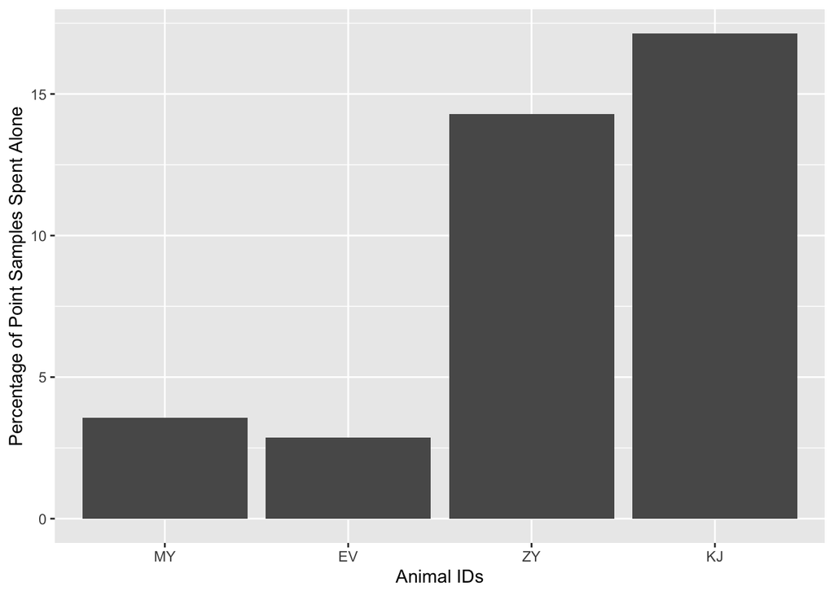

```r
#FIG 1.
g<- ggplot(data=ranks, aes(x=IDs, y=perc_alone))
g<- g + geom_bar(stat= "identity")
g<- g + labs(x="Animal IDs", y= "Percentage of Point Samples Spent Alone")
g
```

*Figure 1. The percentage of 2-min sample points in which no troop member was in contact or <1m away from the focal animal. Animals are arranged according to their designated ranking order in descending order from left to right.*

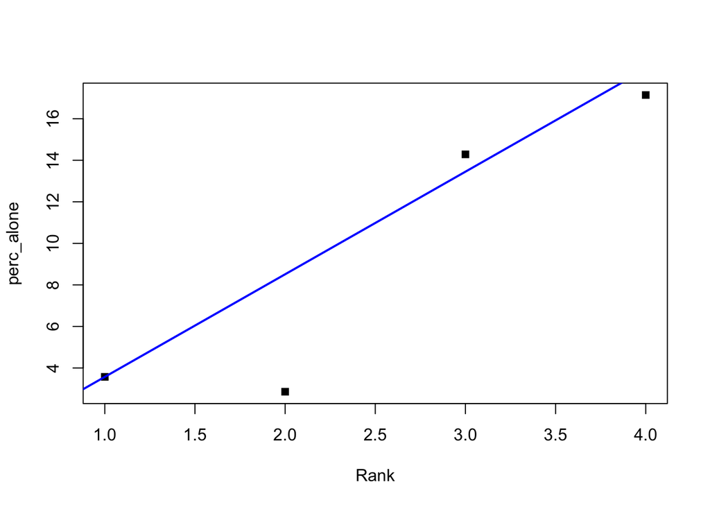

```r
#FIG 2.
plot(perc_alone ~ Rank,
     data = ranks,
     pch  = 15)

abline(model.k,
       col="blue",
       lwd=2)
```

*Figure 2. The relationship between the dominance rank (MY= 1,EV= 2,ZY= 3,KJ= 4) and the percentage of time each individual spent alone (no other individual in contact or <1m away from the focal).*

## Discussion

The main purpose of this study was to practice collecting behavioral data on a troop of captive ring-tailed lemurs (*Lemur catta*) and to investigate how their dominance rank effects grooming behaviors and social proximity. I hypothesized that 1) the male will greet the females more than *vice versa*, 2) subordinate individuals will initiate grooming bouts with dominant individuals more often than *vice versa*, 3) dominant individuals will end grooming bouts more often than *vice versa*, and 4) subordinate individuals will spend more time alone than dominant individuals.

My first hypothesis is supported by the use of greeting behaviors as a rank determinant. King Julian greeted all three females more often than they greeted him in return, designating him the lowest ranking individual in the troop. This mirrors previous studies, which confirm that ring-tailed lemurs form female-dominant social structures both in the wild and in captivity (Jolly 1996; Kappeler 1990; Budnitz and Dainis, 1975; Taylor 1986). My dominance hierarchy determination closely reflects the known kinship of this troop with only one discrepancy (See *Greeting Matrix*). According to the zookeepers, Everest is the breeding female and the mother of both May and Zoey. Nakamich & Koyama (1996) found all mothers in two separate, wild troops of ring-tailed lemurs maintain dominance over their adult daughters. Therefore, I predicted that Everest would receive the most greetings and greet the least in return, designating her the alpha female. The greeting matrix indicates that Everest approached and/or greeted May more than double the amount of times May approached and/or greeted her in return. Because of this, I assigned May the highest-ranking position. However, I question if a small, captive troop such as this follows the expected dominance hierarchical behaviors, especially, since minimal agonistic interactions were observed over the entire course of behavior observations, which is the most common way to determine rank in larger, more complex troops.

My second and third hypotheses regarding grooming bouts between subordinate and dominant individuals were not supported by my results. Table 2 shows no significant difference between the percentage of time subordinates initiated grooming with a dominant individual and/or engaged in unidirectional grooming with a dominant (with no grooming reciprocated from dominant) and *vice versa*. Table 3 shows a similar comparison between subordinate and dominant grooming bout terminations. Closely related adult females, including sisters and mother-daughter dyads, tend to engage in frequent grooming interactions with each other, while most females without close kin do not (Nakamich & Koyama, 1996). A high occurrence of grooming interactions in such a small troop of related female lemurs may not reflect a clear, dominance driven grooming hierarchy as expected.

Lastly, the results mostly support my hypothesis that lower-ranking individuals will spend more time alone than higher-ranking individuals. May and Everest, the two-highest ranking troop members, spent the lowest percentage of time alone while Zoey and King Julian, the two-lowest ranking members, spent much more time alone (Fig. 1). These results are similar to Nakamich & Koyama (1996), who found a similar pattern in the two wild troops they studied. Also, Gould (1996) found females to be mainly responsible for proximity maintenance of male-female dyads. This could explain why King Julian spent the greatest percentage of time alone, since he is the only male in the troop. There seems to be a positive correlation between the dominance rank order and the amount of time each individual spent alone (Fig. 2); however, tests do not show this to be a significant correlation.

The research presented here is my introduction on conducting behavioral observations on a group of captive lemurs and analyzing behavioral data in R. Even though this small group of ring-tailed lemurs did not display all of the social interactions as expected, their behaviors still suggest the presence of a female-dominant social structure with close kinship relations. It has been suggested that female ring-tailed lemurs are less stable in their dominance hierarchy than males and may change ranks throughout various breeding seasons (Taylor 1986). Social rankings among females may therefore be more fluid in nature and subject to change. Furthermore, captive lemurs in such small troop sizes, as seen in this study, who have minimal competition for food and don’t engage in mate selection, may possess an even less concrete dominance hierarchy than larger troops both in captivity and in the wild.

#### References

Altmann, J. (1974). Observational study of behaviour: Sampling methods. *Behaviour* 49: 227-265.

Budnitz, N., and Daiis, K. (1975). Lemur catta: Ecology and behavior. In Tattersall, I., and Sussman, R, W. (eds.), Lemur Biology, Plenum, New York, pp. 219-235.

Gould, L. (1996). Male-female affiliative relationships in naturally occurring ringtailed lemurs (*Lemur catta*) at the Beza-Mahafaly Reserve, Madagascar. Am. J. *Primatol*. 39: 63-78.

Jolly, A. (1966). Lemur Behavior, University of Chicago Press, Chicago and London.

Kappeler PM: Female dominance in Lemur catta: More than just female feeding priority? *Folia Primatol* 1990;55:92–95.

Nakamich, M., & Koyama, N. Social Relationships Among Ring-Tailed Lemurs (*Lemur catta*) in Two Free-Ranging Troops at Berenty Reserve, Madagascar. *International Journal of Primatology*, Vol. 18, No. 1, 1997.

Sauther, M., L. Interplay of Phenology and Reproduction in Ring-Tailed Lemurs: Implications for Ring-Tailed Lemur Conservation. *Folia Primatol* 1998:309–320

Taylor, L: Kinship, Dominance, and Social Organization in a Semi Free-ranging Group of Ringtailed Lemurs (*Lemur catta*); PhD thesis, Washington University, 1986.